# EDRM 718 Sp21: Exercise Set E

Geophrey O. Odero

19 March, 2021

**Directions:** *Complete this assignment in an R notebook. Make sure to number each item, but it is optional for you to copy the prompt for the item. Make sure that your notebook is neat and organized and that all your code chunks run without error, even after clearing the environment. Include both the exercise set letter and your name in your notebook filename. When you are finished, push your repository to GitHub. (Four points per item unless stated otherwise.)*

*Use ggplot2 (part of the tidyverse package) for all graphs in this assignment. Use captions to indicate figure numbers and descriptions, then refer to these numbers in accompanying narrative that briefly describes your main findings. Use the HSB2 data for Part I.*

# Part I

Question #1). **Create a histogram of math scores.**

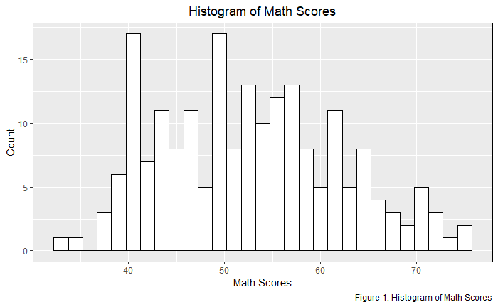

Question #2). **Create a scatterplot to illustrate the relationship of math and science scores. Put math on the horizontal axis.**

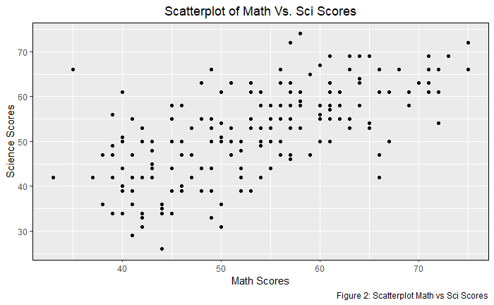

Question #3). **Create a scatterplot to illustrate the relationship of math and science scores. Put math on the horizontal axis. Use different colors to indicate the SES for each student in the plot.**

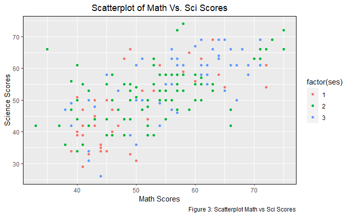

Question #4). **Create a scatterplot to illustrate the relationship of math and science scores. Put math on the horizontal axis. Use different colors to indicate the SES for each student in the plot. Put a linear regression line on your plot.**

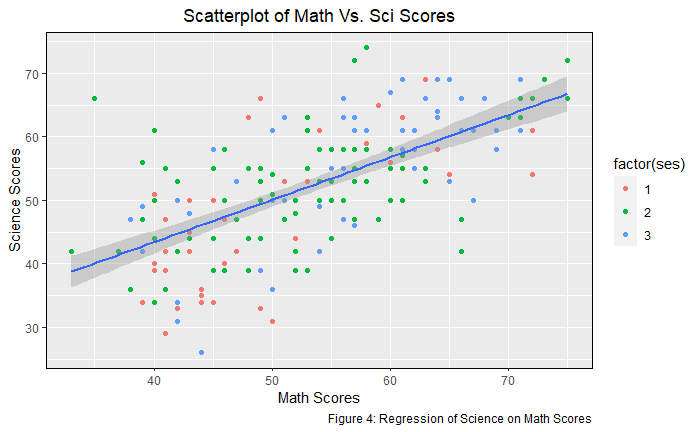

Question #6). **Create two faceted scatterplots to illustrate the relationship of math and science scores: one for private school students and one for public school students. Put math on the horizontal axis of each plot. Use different colors to indicate the SES for each student in the plots. Put a linear regression line on your plots.**

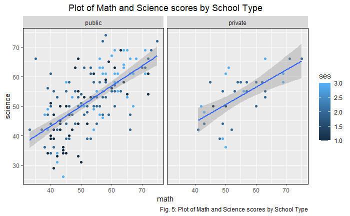

Question #7). **Create side-by-side boxplots to illustrate the differences in math scores of students from different SES groups.**

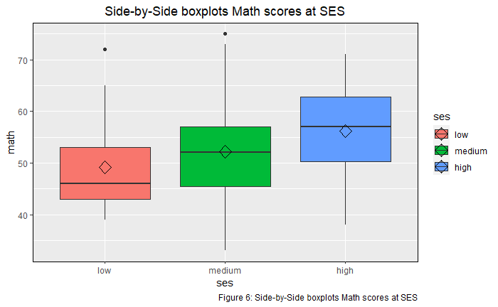

Question #8). **Create side-by-side boxplots to illustrate the differences in math scores of students from different SES groups. Include points for every student in your plot.**

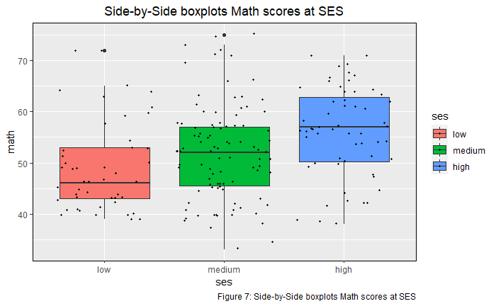

Question #9). **Create side-by-side boxplots to illustrate the differences in math scores of students from different SES groups. Include points for every student in your plot. Also plot the mean for each group.**

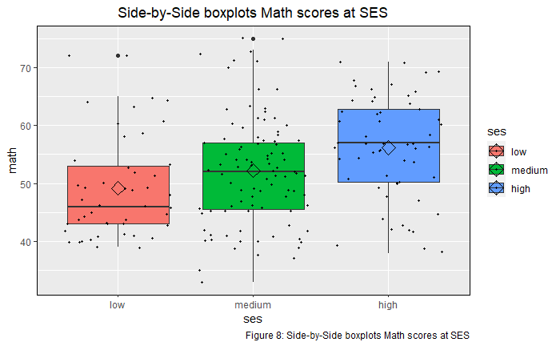

Question #10). **Create stacked bar plots to illustrate how SES groupings is related to the private-public school distinction. Plot proportions on the vertical axis.**

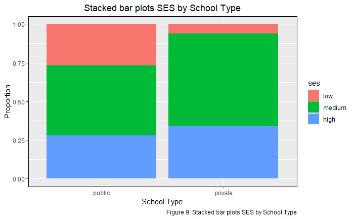